# Introduction

# Bivariate Analysis

### Talk about some of the relationships you observed in this part of the investigation. How did the feature(s) of interest vary with other features in the dataset?

The relationship between quality and alcohol because alcohol is the strongest correlated varible by quality and in the first the realtionship, it’s diffcult to see because the value of records on the quality variable is integer and most of points ploting over each other, to sovle this problem I use jitter and transparing function to help me to see the relationship.

The force for this graph and relationships help me to the effect of the other variable on the qulity in multigraph.

### Did you observe any interesting relationships between the other features (not the main feature(s) of interest)?

Alcohol and Chlorides , Alcohol and Residual.Sugar

In this section I’ll add each of theses variables (density, residual.sugar, chlorides, volatile.acidity) to see reacttion for every one on quality and alcohol scatter plot after update in the bivariatte plots section.

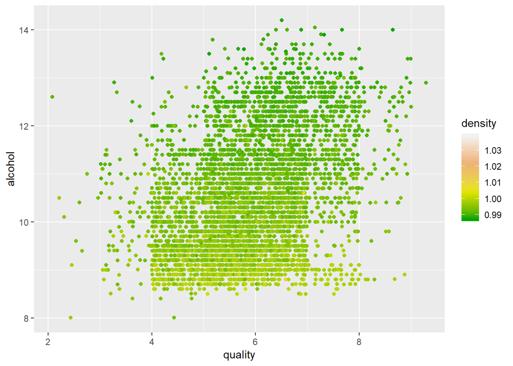

Don’t see much variation on Density when hold the alcohol as aconstant, we don’t see any change in the color.

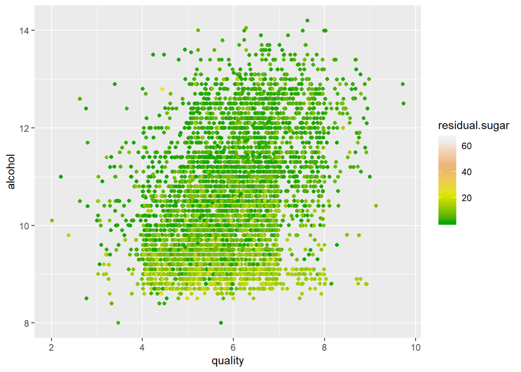

perrty see variation on residual.sugar when hold the alcohol as aconstant, but don’t seq. then we don’t get best information on this.

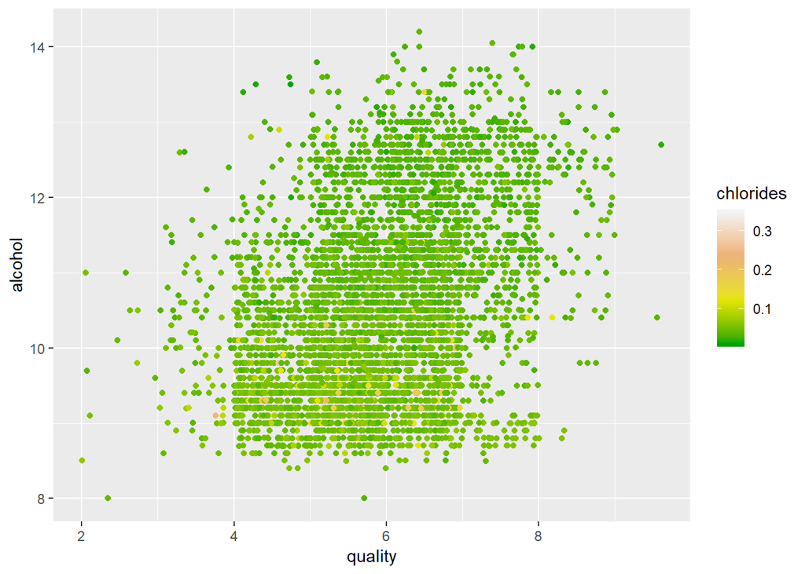

perrty see variation on chlorides when hold the alcohol as aconstant, but don’t seq. then we don’t get best information on this.

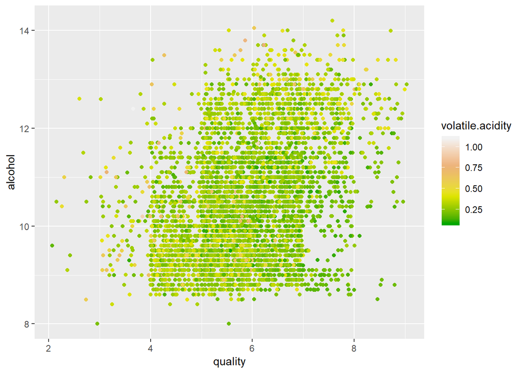

perrty see variation on volatile.acidity when hold the alcohol as aconstant, but don’t seq. then we don’t get best information on this.

After I these plot I don’t get any good information help to understand the variable that have storng effect on quality like alcohol and other variables have small effect we can make model to compute this effect.

```
##
## Calls:
## m1: lm(formula = I(quality) ~ I(alcohol), data = whitewine)
## m2: lm(formula = I(quality) ~ I(alcohol) + density, data = whitewine)
## m3: lm(formula = I(quality) ~ I(alcohol) + density + chlorides, data = whitewine)
## m4: lm(formula = I(quality) ~ I(alcohol) + density + chlorides +
##     residual.sugar, data = whitewine)
## m5: lm(formula = I(quality) ~ I(alcohol) + density + chlorides +
##     residual.sugar + volatile.acidity, data = whitewine)
## m6: lm(formula = I(quality) ~ I(alcohol) + density + chlorides +
##     residual.sugar + volatile.acidity + pH, data = whitewine)
##
## ========================================================================================================
##                          m1            m2            m3            m4            m5            m6
## --------------------------------------------------------------------------------------------------------
##   (Intercept)           2.582***    -22.492***    -21.150***     87.563***     73.271***     96.932***
##                        (0.098)       (6.165)       (6.162)      (12.392)      (11.999)      (12.436)
##   I(alcohol)            0.313***      0.360***      0.343***      0.237***      0.283***      0.251***
##                        (0.009)       (0.015)       (0.015)       (0.018)       (0.018)       (0.019)
##   density                            24.728***     23.671***    -84.931***    -70.514***    -95.761***
##                                      (6.079)       (6.074)      (12.340)      (11.949)      (12.455)
##   chlorides                                        -2.382***     -1.776**      -0.692        -0.373
##                                                    (0.558)       (0.555)       (0.540)       (0.539)
##   residual.sugar                                                  0.052***      0.052***      0.064***
##                                                                  (0.005)       (0.005)       (0.005)
##   volatile.acidity                                                             -2.044***     -2.016***
##                                                                                (0.110)       (0.109)
##   pH                                                                                          0.524***
##                                                                                              (0.077)
## --------------------------------------------------------------------------------------------------------
##   R-squared             0.190         0.192         0.195         0.212         0.264         0.271
##   adj. R-squared        0.190         0.192         0.195         0.211         0.263         0.270
##   sigma                 0.797         0.796         0.795         0.787         0.760         0.757
##   F                  1146.395       583.290       396.315       328.736       351.293       303.254
##   p                     0.000         0.000         0.000         0.000         0.000         0.000
##   Log-likelihood    -5839.391     -5831.127     -5822.011     -5771.696     -5603.301     -5580.047
##   Deviance           3112.257      3101.773      3090.247      3027.406      2826.235      2799.526
##   AIC               11684.782     11670.255     11654.021     11555.391     11220.603     11176.094
##   BIC               11704.272     11696.241     11686.504     11594.371     11266.079     11228.067
##   N                  4898          4898          4898          4898          4898          4898
## ========================================================================================================
```

# Multivariate Analysis

### Talk about some of the relationships you observed in this part of the investigation. Were there features that strengthened each other in terms of looking at your feature(s) of interest?

I don’t get new relationship in this section because the quality is mostly depended on the amount of alcohol.

### Were there any interesting or surprising interactions between features?

surprising because only one variabel has strong impact on grade of quality.

### OPTIONAL: Did you create any models with your dataset? Discuss the strengths and limitations of your model.

# Final Plots and Summary

### Plot One

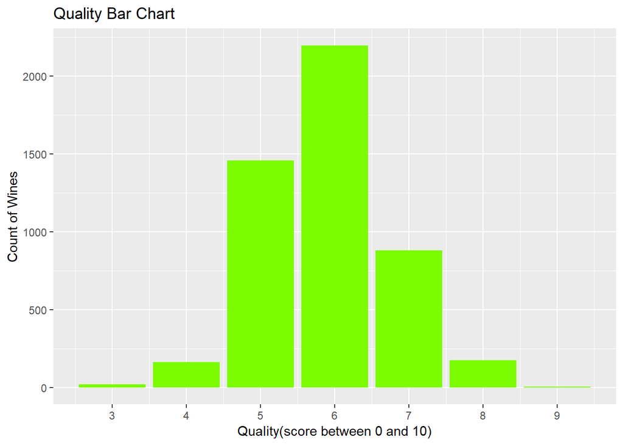

### Description One

This is the bar Chart for quality variable because quality is integer data type and have only 7 values along the data, and the max number of wines have quality grade equal 6 , min number of wines have quality grade equal 9.

### Plot Two

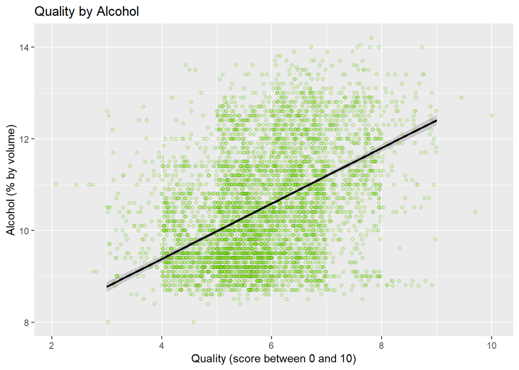

### Description Two

Descripe the relationship between quality and alcohol by scatter plot but we have problem overploting and quality is integer we need spread point along x-axis, then I applied jitter function and transparing function alpha to solve these problem and after solve, I want to know the relationship between varibales then I make line smooth to know " as Alcohol increases the Quality increases"

### Plot Three

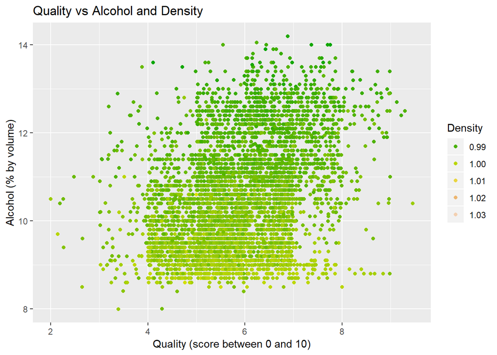

### Description Three

This is the plot 2 but I add Density variable as color to see the relationship between three variables, the result I didn’t show extremly relationship in this graph, because the color of density dependent on y variable “Alcohol” and indpendent on x variable “Quality”.

# Reflection

I was surpriesd that only one has strong relationship to the quality grade this variable is alcohol and some other variables have weak relationship these variables are density, residual.sugar, chlorides, pH, and volatile.acidity and others nearly zero relationship to quality grade.

The model was able to account for 27.1% of the variance in the dataset, I have some limitations of this model include the source of The data, I would be interested in testing the linear model to predict current grade of quality and to determine to what extent model is accurate at grading quality of white winse.